# Linear Algebra

## Section 1 - Scalars Vectors and Matrices

- Scalar - a constant
- Vector - a single row or column of numbers
- Matrix - a rectangular collection of numbers
- Dimensions - refer to the number of rows and columns
  - an rxc matrix - r rows and c columns
  - The m<sub>ij</sub> element is at row i and column j
- Vectors are a subset of matrices
  - Either dimensions 1xc (a row vector) or rx1 (a column vector)
  - And scalars are 1x1
- Vectors are used to represent a location in space. Each entry represents a dimension. This is easy to see in 1, 2 and 3 dimensions
- Vectors are arrows, whenever we get beyond a single dimension

## Section 2 - Application Scalars Vectors and Metrics

1. Defining a vector [c(), :, seq(), rep()]
- R is fully vectorized - default process is to think in terms of vectors (i.e. a collection of elements)

```r
# Using the c() function
v1 <- c(2, 3, 4, 5)
str(v1)
# Using the ':' operator
v2 <- 2:5 # From 2 to 5, default counter 1

# USing the seq() function; a long-form version of the ':' operator
v3 <- seq(from = 2, to = 5, by = 1)

# OR...
v3 <- seq(2, 5, 1)

# Using the rep() function
v4 <- rep(37, 5)  # Repeats 37 5x times
```

[output not shown]

2. Defining a matrix [matrix(), rbind(), cbind()]
- A matrix is just a collection of vectors

```r
m2
```

```
     [,1] [,2] [,3]
[1,]    1    2    3
[2,]    4    5    6
```

3. Plots in 2D and 3D
- Vector in 2-space

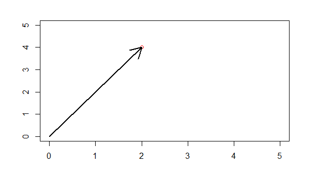

- Vector in 3-space

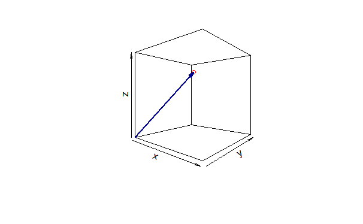

## Section 2 - LAB1 - Intro Scalars Vectors and Matrices

1. Create a 3x4 matrix, A, fill row-wise with the number 1-12. What is a<sub>24</sub>?

```r
A <- matrix(seq(1,12,1), nrow = 3, ncol = 4, byrow = TRUE)
A
```

```
     [,1] [,2] [,3] [,4]
[1,]    1    2    3    4
[2,]    5    6    7    8
[3,]    9   10   11   12
```

```r
A[2,4]
```

```
[1] 8
```

2. Create two 1x2 vectors, v1 and v2, with numeric entities of your choice. Plot v1 and v2 on the same coordinate plane

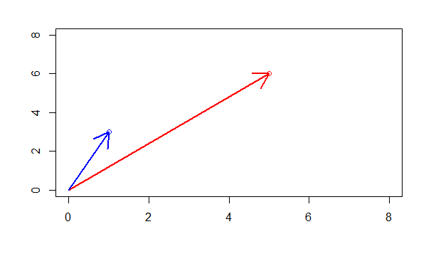

3. Now add 3 to the second entry in v1 and re-plot. Describe the position of the new vector in 2-space relative to v1

```r
v2_b <- c(v1[1], v1[2] +3)
v2_b
```

```
[1] 5 9
```

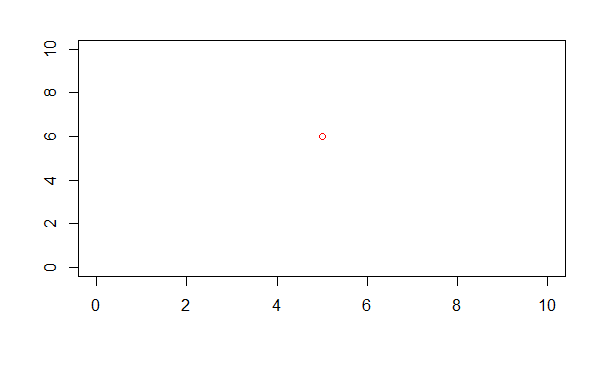

```r
plot(v1[1], v1[2], type = 'p', col = 'red',
     xlim = c(0,10), ylim = c(0,10),
     xlab = "", ylab = "")
```

```r
plot(v2_b[1], v2_b[2], type = 'p', col = 'blue',
     xlim = c(0,10), ylim = c(0,10),
     xlab = "", ylab = "")
arrows(x0 = 0, y0 = 0,
       x1 = v1[1], y1 = v1[2],
       lwd = 2, col = 'red')
```

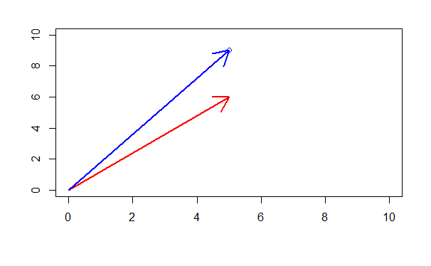

```r
arrows(x0 = 0, y0 = 0,
       x1 = v2_b[1], y1 = v2_b[2],
       lwd = 2, col = 'blue')
```

4. Create a 1x3 vector, v3, with numeric entries of your choice. Plot v3 in 3-space

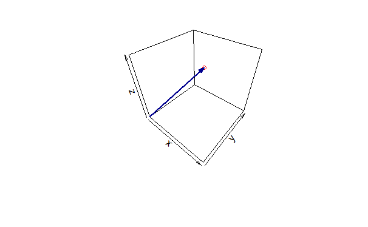

5. Fill in the blanks: A *vector* is a *matrix* with only one *row* or *column*